# Reproducible Research: Peer Assessment 1

## Loading and preprocessing the data

Loading the required package for this data analysis:

```r
library(ggplot2)
library(plyr); library(dplyr)
```

The ‘activity.csv’ dataset I had save into my local hard drive. I read the CSV file from my local drive to R environment and save as ‘activity’ data frame:

```r
activity <- read.csv('D:/DIR_R/activity.csv')
```

The structure of the data set:

```r
str(activity)
```

```
## 'data.frame':    17568 obs. of  3 variables:
##  $ steps   : int  NA NA NA NA NA NA NA NA NA NA ...
##  $ date    : Factor w/ 61 levels "2012-10-01","2012-10-02",..: 1 1 1 1 1 1 1 1 1 1 ...
##  $ interval: int  0 5 10 15 20 25 30 35 40 45 ...
```

The dimension of the data set:

```r
dim(activity)
```

```
## [1] 17568     3
```

## What is mean total number of steps taken per day?

For this section, I removed all NA’s before perform descriptive analysis (mean and median), using ‘complete.cases’.

```r
activity <- activity[complete.cases(activity), ]
```

I used plyr package to find the total number of steps taken per day. The value is stored as total_steps.

```r
total_steps <- ddply(activity, c("date"), summarise, TotalSteps = sum(steps))
```

The mean and median total number of steps taken per day:

```r
mean(total_steps$TotalSteps)
```

```
## [1] 10766.19
```

```r
median(total_steps$TotalSteps)
```

```
## [1] 10765
```

Histogram of the total number of steps taken each day:

```
## stat_bin: binwidth defaulted to range/30. Use 'binwidth = x' to adjust this.
```

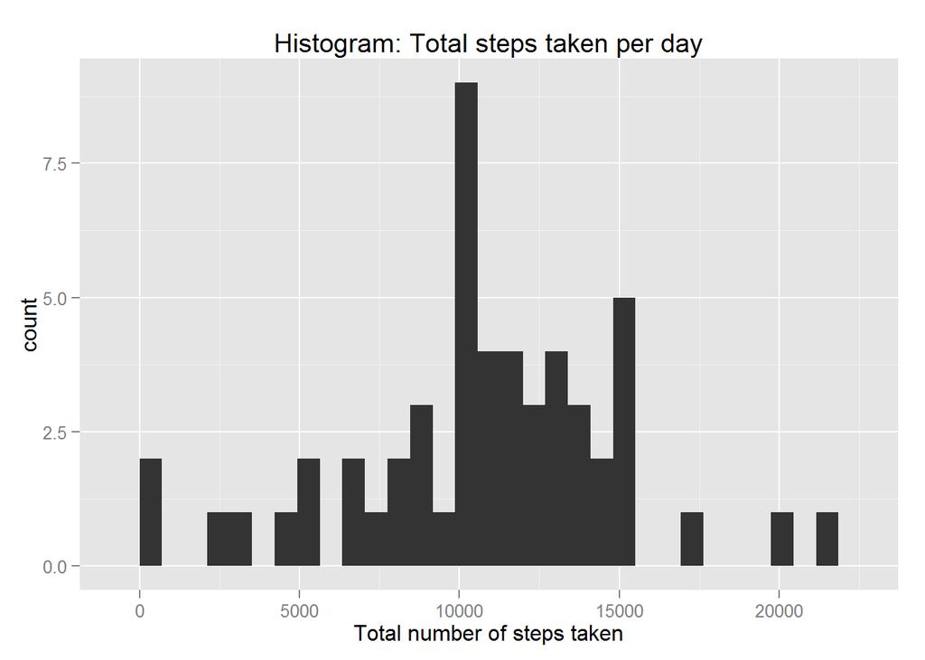

```r
ggplot(total_steps, aes(x = TotalSteps)) + geom_histogram() + xlab("Total number of steps taken") + ggtitle("Histogram: Total steps taken per day")
```

## What is the average daily activity pattern?

I used plyr package to find the average number of steps taken across all days within 5-minute interval. The value is stored as mean5m.

```r
mean_5m <- ddply(activity, c("interval"), summarise, Mean5m = mean(steps))
```

Time series plot of the 5-minute interval and the average number of steps taken, averaged across all days.

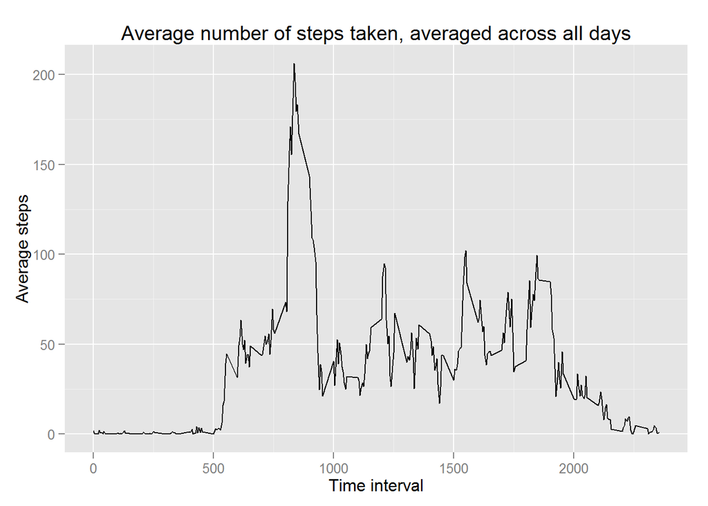

```r
ggplot(mean_5m, aes(x = interval,y = Mean5m)) + geom_line() + xlab("Time interval") + ylab("Average steps") + ggtitle("Average number of steps taken, averaged across all days")
```

## Imputing missing values

Starting this section, I reload the original data set again because previous section I had removed the NA’s in the original data frame. The original data frame is stored as ‘activity_2’.

```r
activity_2 <- read.csv('D:/DIR_R/activity.csv')
```

Total NA’s in the activity data set:

```r
sum(is.na(activity_2))
```

```
## [1] 2304
```

The original dataset have some missing value, my strategy for filling in all of the missing values in this dataset is **replace the NA’s to 0**. The following code will perform this step:

```r
activity_2[is.na(activity_2)] <- 0
```

As usual, I used plyr package to help me calculate the total steps per day and within 5-minute interval:

```r
total_steps_2 <- ddply(activity_2, c("date"), summarise, TotalSteps = sum(steps))

mean_5m_2 <- ddply(activity_2, c("interval"), summarise, Mean5m = mean(steps))
```

The mean and median of the data (NA’s is replaced with 0).

```r
mean(total_steps_2$TotalSteps)
```

```
## [1] 9354.23
```

```r
median(total_steps_2$TotalSteps)
```

```
## [1] 10395
```

Histogram of the total number of steps taken each day (NA’s is replaced with 0):

```
## stat_bin: binwidth defaulted to range/30. Use 'binwidth = x' to adjust this.
```

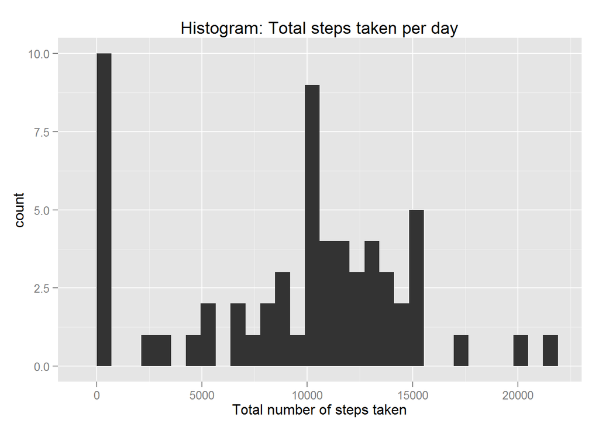

```r
ggplot(total_steps_2, aes(x = TotalSteps)) + geom_histogram() + xlab("Total number of steps taken") + ggtitle("Histogram: Total steps taken per day")
```

## Are there differences in activity patterns between weekdays and weekends?

For this section, I perform some operation on the “date” section to the ‘activity_2’ dataset.

```r
activity_2$date <- as.Date(activity_2$date)

WDays <- c('Monday', 'Tuesday', 'Wednesday', 'Thursday', 'Friday')

activity_2$WeekDays <- factor((weekdays(activity_2$date) %in% WDays), levels = c(FALSE, TRUE), labels = c('weekend', 'weekday'))
```

I used dplyr package to help me perform this part of analysis to filter out weekday and weekend on the activity_2 data frame. Later on, I used plyr package to help me compute the mean steps taken, based on 5-minute interval, averaged across all days.

```r
data_weekend <- filter(activity_2, WeekDays == "weekend")
data_weekday <- filter(activity_2, WeekDays == "weekday")

weekend_sum <- ddply(data_weekend, c("interval", "WeekDays"), summarise, TotalSteps = mean(steps))

weekday_sum <- ddply(data_weekday, c("interval", "WeekDays"), summarise, TotalSteps = mean(steps))

DF_WeekDay <- rbind(weekday_sum, weekend_sum)
```

Based on the graph below, we can see significant difference on the steps, especially at the time interval of 1000-2000.

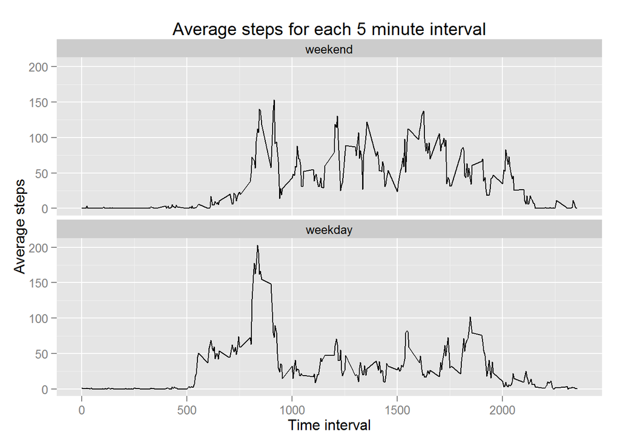

```r
ggplot(DF_WeekDay, aes(x = interval, y = TotalSteps)) + facet_wrap(~WeekDays, nrow = 2, ncol = 1) + xlab("Time interval") + ylab("Average steps") + geom_line() + ggtitle("Average steps for each 5 minute interval")
```